# ZEAL/BZea Leaves-Above-Ear (LAE) GWAS + JLM on the SNP50K panel — FDR ≤ 0.05

- Show All Code
- Hide All Code
- View Source

The leaf-number analog of the EN/EH notebooks: same SNP50K ancestry pipeline, phenotype = per-field SpATS leaves-above-ear BLUEs (CLY25 only), candidate = tunicate1 (tu1/ZMM19), a MADS-box gene reported to control leaf/node number. Significance is Benjamini–Hochberg FDR ≤ 0.05 (per-scan q-values): the Manhattan line is the −log₁₀P at which BH q = 0.05, and candidate/peak calls report q.

Author

Fausto Rodríguez-Zapata

Published

July 13, 2026

**What this is.** The leaves-above-ear (LAE) sibling of `zeal-qtl-recovery-en-mlm-snp50k-fdr`, built from the same real BZea pipeline end-to-end: field LAE → SpATS spatial BLUEs → SNP50K teosinte-ancestry dosage → RTIGER ancestry mosaic → K → JLM + MLM. The population is the same near-isogenic B73×teosinte BC2S3 lines from **5 teosinte taxa**. LAE is the **number of leaves above the uppermost ear** — a node/leaf-number count (B73 ≈ 5.7). It was scored **CLY25 only**, so the per-genotype value is the single-field SpATS BLUE. Only the phenotype and the candidate change vs the EN notebook.

**ImportantGenotype at 0.4× skim: why ancestry, not per-SNP**

SNP50K is 51,991 teosinte-vs-B73 sites pileup-genotyped at ~0.4× — hard genotypes are unusable (70% missing, ~0% hom-ALT), so ancestry is inferred from the per-sample allele **counts**. The **per-SNP genotype (bcftools HWE-posterior) (Panel B)** is therefore λ_GC-deflated (sparse mean-imputation); the **RTIGER ancestry mosaic (Panel C)** is the usable, block-smoothed genotype (teosinte presence 0.111, matching the established BzeaSeq ~0.101). This is the SNP50K-specific reason ancestry inference is mandatory, and is identical to the DTA/PH/EH/EN notebooks — only the phenotype changes.

**Trait context.** Leaf number above the ear is a **vegetative-architecture / node-number** trait, set by the number of phytomers the shoot apical meristem produces above the ear-bearing node and tightly linked to flowering time and total leaf number. The single a-priori candidate here is **`tu1` (tunicate1 / ZMM19)** — the classical **pod-corn** MADS-box transcription factor (dominant *Tu* elongates the glumes so they enclose the kernel), which the cited study (*Nat Commun* 2024, doi:10.1038/s41467-024-54148-7) implicates in **leaf/node number**. `tu1` sits on **chr 4 at ~183.9 Mb** (v5). As in DTA/EN, teosinte ancestry is broadly node-number-shifting and **partly collinear with K**, so the mixed model absorbs ancestry-correlated variance and the model-independent **JLM** (nested-in-family stepwise) is the primary QTL tool.

**NoteSingle-candidate panel**

```r
library(here)
library(data.table)
library(ggplot2)
library(fastman)
library(ggrepel)
library(ggtext)
library(scales)
library(cowplot)
source(here("scripts/teonam_notebook_plots.R")) # shared: plot_manhattan/lollipop, lambda_gc, LOD
```

```r
mlm <- fread(here("data/zeal/lae_gwas_mlm_rtiger_mosaic_donor_accession_snp50k.csv")) # Panel C
gt <- fread(here("data/zeal/lae_gwas_mlm_hwe_post_gt_donor_accession_snp50k.csv")) # Panel B
ols <- fread(here("data/zeal/lae_gwas_ols_donor_accession_snp50k.csv"))[is.finite(P) & P > 0]
overlap <- here("results/sim/zeal/lae_candidate_overlap.csv")
lam <- function(p) {
  p <- p[is.finite(p) & p > 0 & p <= 1]
  round(median(qchisq(p, 1, lower.tail = FALSE)) / qchisq(0.5, 1), 2)
}
ALPHA <- 0.05
# -log10P threshold at Benjamini-Hochberg FDR <= ALPHA (NA if no marker passes)
fdr_lod <- function(p, alpha = ALPHA) {
  p <- p[is.finite(p) & p > 0]
  q <- p.adjust(p, "BH")
  if (!any(q <= alpha)) {
    return(NA_real_)
  }
  -log10(max(p[q <= alpha]))
}
qval <- function(p) p.adjust(p, "BH") # BH q-values aligned to p
```

**NoteSignificance = Benjamini–Hochberg FDR ≤ 0.05**

## Candidate gene: closest marker vs window-max marker

For the LAE candidate (B73 v5), the closest marker to the gene body vs the highest −log₁₀P marker within ±500 kb in the RTIGER-mosaic **MLM (Taxon+K)** scan (Panel C).

```r
sc <- copy(mlm)[is.finite(P) & P > 0][, logP := -log10(P)][, q := qval(P)]
gg <- fread(here("data/teonam/lae_candidate_genes.tsv"))
gg[, chr := as.integer(chr)][, qtl := ifelse(qtl_chen2019 == "" | is.na(qtl_chen2019), paste0("LAE(chr", chr, ")"), qtl_chen2019)]
WIN <- 5e5
ctab <- rbindlist(lapply(seq_len(nrow(gg)), function(i) {
  ch <- gg$chr[i]
  s <- gg$start[i]
  e <- gg$end[i]
  m <- sc[CHR == ch]
  if (!nrow(m)) {
    return(NULL)
  }
  d <- pmax(0L, pmax(s - m$BP, m$BP - e))
  kc <- which.min(d)
  w <- m[BP >= s - WIN & BP <= e + WIN]
  kw <- if (nrow(w)) which.max(w$logP) else NA
  data.table(
    gene = gg$symbol[i], pathway = gg$pathway[i], chr = ch, `gene start (v5)` = s,
    `closest Δstart (bp)` = m$BP[kc] - s, `closest -log10P` = round(m$logP[kc], 2),
    `window-max -log10P` = if (nrow(w)) round(w$logP[kw], 2) else NA_real_,
    `window-max q (BH)` = if (nrow(w)) signif(w$q[kw], 2) else NA_real_,
    `FDR<=0.05` = if (nrow(w)) w$q[kw] <= ALPHA else NA
  )
}))
setorder(ctab, chr, `gene start (v5)`)
knitr::kable(ctab,
  format.args = list(big.mark = ","),
  caption = "LAE candidate (B73 v5; tu1/tunicate1): closest vs window-max (±500 kb) marker, RTIGER-mosaic MLM (Taxon+K) scan, with Benjamini–Hochberg q at the window-max marker."
)
```

LAE candidate (B73 v5; tu1/tunicate1): closest vs window-max (±500 kb) marker, RTIGER-mosaic MLM (Taxon+K) scan, with Benjamini–Hochberg q at the window-max marker.

| gene | pathway | chr | gene start (v5) | closest Δstart (bp) | closest -log10P | window-max -log10P | window-max q (BH) | FDR<=0.05 |
| --- | --- | --- | --- | --- | --- | --- | --- | --- |
| tu1 | Tier1 — MADS-box TF (ZMM19); tunicate1 (ZMM19), the classical pod-corn MADS-box gene (elongated glumes enclosing kernels); reported to control leaf/node number, relevant to leaves-above-ear (LAE) | 4 | 183,877,026 | -2,231 | 0.31 | 0.43 | 0.92 | FALSE |

## OLS → MLM: structure control

The fixed-effect OLS (Taxon + marker, no K) vs the MLM (Taxon + K) on the RTIGER mosaic, same fixed part. OLS is intrinsically inflated (ancestry-block LD, unfixable by any fixed factor); K deflates λ toward 1 and removes the ancestry-correlated bulk that a near-isogenic, teosinte-ancestry-structured node-number panel carries.

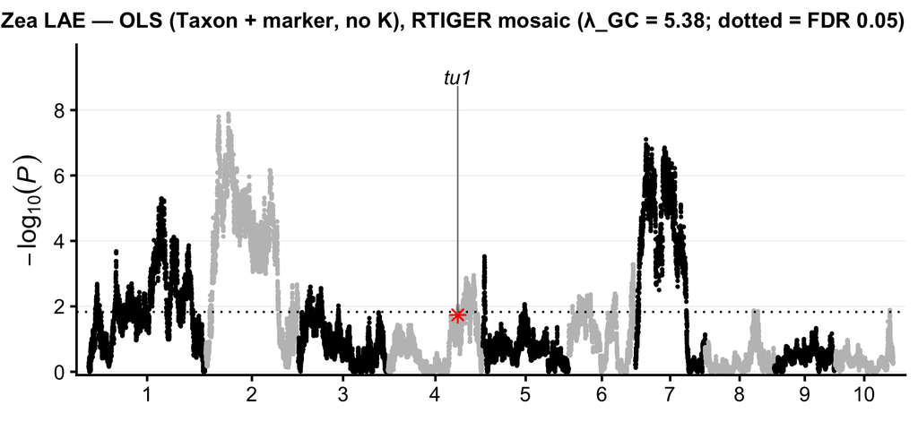

```r
plot_manhattan(ols,
  sprintf("ZEAL/BZea LAE — OLS (Taxon + marker, no K), RTIGER mosaic (λ_GC = %.2f; dotted = FDR 0.05)", lam(ols$P)),
  overlap_csv = overlap, lod = fdr_lod(ols$P),
  out_png = here("results/sim/zeal/lae_gwas_ols_manhattan_fdr_snp50k.png")
)
```

The OLS Manhattan (no K) is genome-wide inflated (ancestry-block LD) — the same structure artifact the MLM K term removes below.

```r
lam_tab <- data.table(
  model = c("OLS (Taxon + marker, no K)", "MLM (Taxon + K)"),
  markers = c(nrow(ols), nrow(mlm)),
  lambda_GC = c(lam(ols$P), lam(mlm$P)),
  `n FDR<=0.05` = c(sum(qval(ols$P) <= ALPHA), sum(qval(mlm$P) <= ALPHA)),
  max_logP = round(c(max(-log10(ols$P)), max(-log10(mlm$P))), 2)
)
knitr::kable(lam_tab, caption = "OLS vs MLM on the RTIGER mosaic (same Taxon fixed part): K deflates genomic inflation; n markers at BH FDR ≤ 0.05.")
```

OLS vs MLM on the RTIGER mosaic (same Taxon fixed part): K deflates genomic inflation; n markers at BH FDR ≤ 0.05.

| model | markers | lambda_GC | n FDR<=0.05 | max_logP |
| --- | --- | --- | --- | --- |
| OLS (Taxon + marker, no K) | 48900 | 5.38 | 14494 | 7.89 |
| MLM (Taxon + K) | 48900 | 1.13 | 0 | 3.56 |

```r
ov <- fread(overlap)
peak_at <- function(scan, ch, s) {
  w <- scan[CHR == ch & abs(BP - s) <= 5e5 & is.finite(P) & P > 0]
  if (!nrow(w)) NA_real_ else round(max(-log10(w$P)), 2)
}
cmp <- ov[, .(
  gene = symbol, chr,
  `OLS peak` = mapply(peak_at, list(ols), chr, start),
  `MLM peak` = mapply(peak_at, list(mlm), chr, start)
)]
cmp[, `drop (OLS−MLM)` := round(`OLS peak` - `MLM peak`, 2)]
setorder(cmp, -`OLS peak`)
knitr::kable(cmp, caption = "Local peak -log10P (±500 kb) at the candidate: OLS vs MLM. K suppresses the ancestry-collinear signal.")
```

Local peak -log10P (±500 kb) at the candidate: OLS vs MLM. K suppresses the ancestry-collinear signal.

| gene | chr | OLS peak | MLM peak | drop (OLS−MLM) |
| --- | --- | --- | --- | --- |
| tu1 | 4 | 1.74 | 0.43 | 1.31 |

## JLM QTL genomic distribution (Panel A)

LAE QTL from JLM (TASSEL StepwiseOLS, nested in taxon, enter/exit P=1e-4=LOD4). JLM QTL are selected by the stepwise enter/exit P (a model-selection gate), independent of the per-scan FDR line used for the GWAS Manhattans below. Model-independent — the primary LAE analysis, as in Chen 2019.

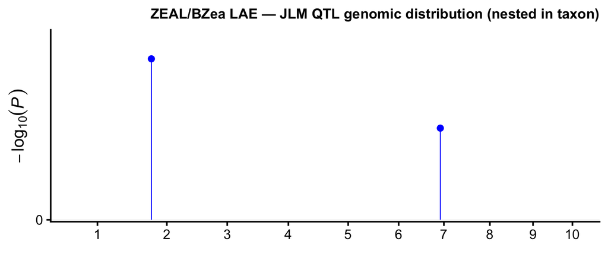

```r
p_lolli <- plot_lollipop(
  here("results/sim/zeal/tassel/lae_jlm_native1.txt"), mlm,
  "ZEAL/BZea LAE — JLM QTL genomic distribution (nested in taxon)",
  overlap_csv = overlap, label_genes = c("tu1"),
  out_png = here("results/sim/zeal/lae_jlm_lollipop_snp50k.png")
)
p_lolli
```

## MLM (Taxon + K), RTIGER ancestry mosaic (Panel C)

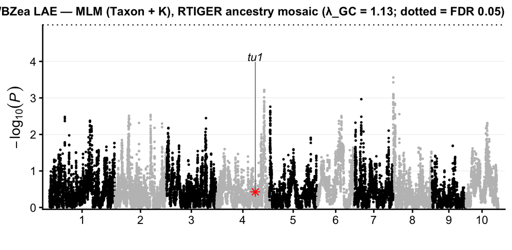

```r
p_mlm <- plot_manhattan(mlm,
  sprintf("ZEAL/BZea LAE — MLM (Taxon + K), RTIGER ancestry mosaic (λ_GC = %.2f; dotted = FDR 0.05)", lam(mlm$P)),
  overlap_csv = overlap, lod = fdr_lod(mlm$P), out_png = here("results/sim/zeal/lae_gwas_mlm_rtiger_mosaic_manhattan_fdr_snp50k.png")
)
p_mlm
```

```r
cat(sprintf("%d markers pass FDR <= 0.05 (BH); FDR line at -log10P = %s\n", sum(qval(mlm$P) <= ALPHA), ifelse(is.na(fdr_lod(mlm$P)), "NA (none)", sprintf("%.2f", fdr_lod(mlm$P)))))
```

```
0 markers pass FDR <= 0.05 (BH); FDR line at -log10P = NA (none)
```

## Composite (A: JLM · B: per-SNP MLM · C: RTIGER-mosaic MLM)

Panel B (per-SNP genotype (bcftools HWE-posterior)) is λ_GC-deflated — the 70%-missing per-SNP panel at 0.4× is sparse — but catches sharp SNP hits the mosaic block-terraces away. Panel C (the ancestry mosaic) is the usable, well-calibrated genotype. The B↔︎C contrast is the notebook’s per-SNP-scatter vs ancestry-block-smoothing, and the demonstration that ancestry inference is mandatory at low coverage — identical in mechanism to the DTA/PH/EH/EN notebooks.

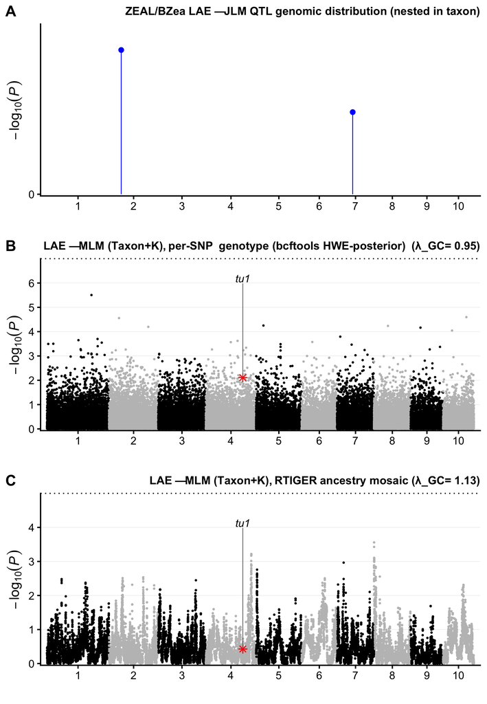

```r
p_B <- plot_manhattan(gt,
  sprintf("LAE — MLM (Taxon+K), per-SNP genotype (bcftools HWE-posterior) (λ_GC = %.2f)", lam(gt$P)),
  overlap_csv = overlap, lod = fdr_lod(gt$P)
)
p_C <- plot_manhattan(mlm,
  sprintf("LAE — MLM (Taxon+K), RTIGER ancestry mosaic (λ_GC = %.2f)", lam(mlm$P)),
  overlap_csv = overlap, lod = fdr_lod(mlm$P)
)
composite <- cowplot::plot_grid(p_lolli, p_B, p_C, ncol = 1, labels = c("A", "B", "C"), label_size = 20, align = "v", axis = "lr")
ggsave(here("results/sim/zeal/lae_composite_snp50k.png"), composite, width = 9, height = 13, dpi = 200, bg = "white")
composite
```

## Multi-caller LAE scan (control · nNIL · RTIGER · LB-Impute · binhmm)

The same LAE MLM (Taxon+K) scan on each ancestry caller’s recovered genotypes, at the real ~0.4× depth (not a coverage sweep). The robust, trait-independent finding is **teosinte-presence recovery**: the block/bin-aggregated callers (RTIGER 0.111; binhmm 0.101) recover the established BzeaSeq fraction (~0.10), while per-SNP calling (control) and the per-SNP HMM recalls (nNIL, LB-Impute) **under-call**. Genomic inflation is phenotype-dependent (reported per caller below). Caller genotypes are population-level and trait-independent; only the phenotype (LAE) changes.

```r
callers <- c(control = "hwe_post_gt", nNIL = "nnil_mosaic", RTIGER = "rtiger_mosaic", `LB-Impute` = "lbimpute_mosaic", binhmm = "binhmm_mosaic")
gg <- fread(here("data/teonam/lae_candidate_genes.tsv"))[, chr := as.integer(chr)]
# best (min-q) LAE candidate window per caller
min_cand_q <- function(sc) {
  q <- qval(sc$P)
  vals <- unlist(lapply(seq_len(nrow(gg)), function(i) {
    idx <- which(sc$CHR == gg$chr[i] & abs(sc$BP - gg$start[i]) <= 5e5)
    if (length(idx)) min(q[idx]) else NA_real_
  }))
  if (all(is.na(vals))) NA_real_ else signif(min(vals, na.rm = TRUE), 2)
}
ctab2 <- rbindlist(lapply(names(callers), function(nm) {
  g <- callers[[nm]]
  sc <- fread(here(sprintf("data/zeal/lae_gwas_mlm_%s_donor_accession_snp50k.csv", g)))
  mf <- here(sprintf("data/zeal/zeal_%s.rds", g))
  pres <- if (file.exists(mf)) {
    st <- readRDS(mf)$state
    round(mean(st %in% c(1L, 2L), na.rm = TRUE), 3)
  } else {
    NA_real_
  }
  sc <- sc[is.finite(P) & P > 0]
  data.table(
    caller = nm, `teosinte presence` = pres, lambda_GC = lam(sc$P),
    `n FDR<=0.05` = sum(qval(sc$P) <= ALPHA),
    `candidate q (BH)` = min_cand_q(sc)
  )
}))
knitr::kable(ctab2, caption = "LAE MLM (Taxon+K) by ancestry caller at 0.4×, with n markers at BH FDR ≤ 0.05 and the q at the tu1 candidate window.")
```

LAE MLM (Taxon+K) by ancestry caller at 0.4×, with n markers at BH FDR ≤ 0.05 and the q at the tu1 candidate window.

| caller | teosinte presence | lambda_GC | n FDR<=0.05 | candidate q (BH) |
| --- | --- | --- | --- | --- |
| control | 0.008 | 0.95 | 0 | 1.00 |
| nNIL | 0.018 | 0.97 | 0 | 1.00 |
| RTIGER | 0.111 | 1.13 | 0 | 0.92 |
| LB-Impute | 0.035 | 0.94 | 0 | 0.99 |
| binhmm | 0.101 | 1.08 | 0 | 0.99 |

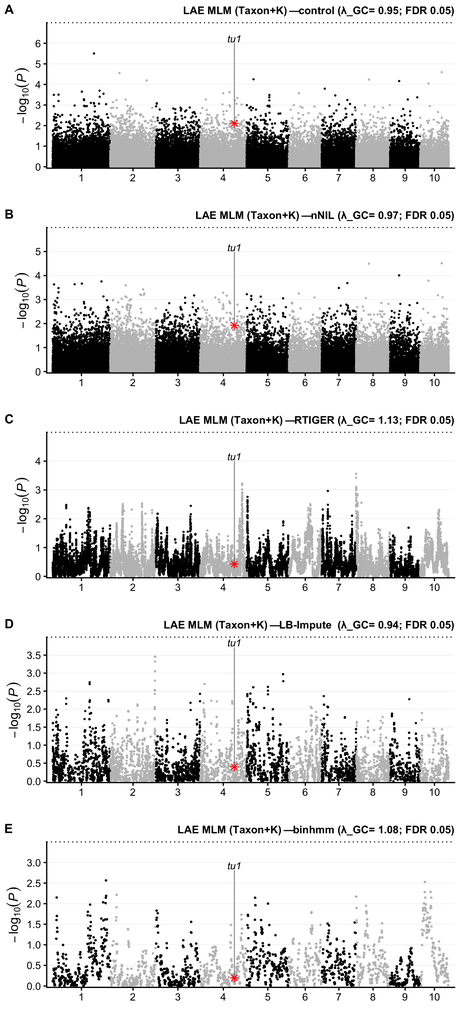

```r
panels <- lapply(names(callers), function(nm) {
  sc <- fread(here(sprintf("data/zeal/lae_gwas_mlm_%s_donor_accession_snp50k.csv", callers[[nm]])))
  plot_manhattan(sc, sprintf("LAE MLM (Taxon+K) — %s (λ_GC = %.2f; FDR 0.05)", nm, lam(sc$P)), overlap_csv = overlap, lod = fdr_lod(sc$P))
})
cc <- cowplot::plot_grid(plotlist = panels, ncol = 1, labels = LETTERS[1:5], label_size = 18, align = "v", axis = "lr")
ggsave(here("results/sim/zeal/lae_caller_composite_fdr_snp50k.png"), cc, width = 9, height = 20, dpi = 200, bg = "white")
cc
```